# VOIP Phones | Assignment 3

Davide Pecchia

9/4/2018

## Introduction

*DM Systems* has agreed to supply 500,000 Voip Phones to *DISCO Stores* in 90 days at fixed price. A key component in the phones is a programmable array logic integrated circuit chip (“PAL chip”), one of which is required in each phone.

DM Systems has bought these chips in the past from an Italian chip manufacturer, *IM Chips*. However, DM Systems has been approached by a Korean manufacturer, *KR Electronics*, which is offering a lower price on the chips. This offer is open for only 10 days, and DM Systems must decide whether to buy some or all of the PAL chips from KR. Any chips that DM does not buy from KR will be bought from IM. IM Chips will sell PAL chips to DM for $3.00 per chip in any quantity. KR will accept orders only in multiples of 250,000 PAL chips, and is offering to sell the chips for $2.00 per chip for 250,000 chips, and for $1.50 per chip in quantities of 500,000 or more chips.

## The dumping charge

The situation is complicated by a dumping charge that has been filed by IM Chips against KR. If this charge is upheld by the Italian government, then the KR chips will be subject to an antidumping tax. This case will not be resolved until after the point in time when DM must make the purchase decision. If DM buys the KR chips, these will not be shipped until after the antidumping tax would go into effect and the chips would be subject to the tax. Under the terms offered by KR, DM would have to pay any antidumping tax that is imposed. DM believes there is a 60% chance the antidumping tax will be imposed. If it is imposed, then it is equally likely that the tax will be 50%, 100%, or 200% of the sale price for each PAL chip.

## The decision tree

Loading libraries

```r
library(yaml)
library(radiant)
library(radiant.model)
library(ggplot2)
```

- Draw a decision tree for this decision.

```r
tree = yaml.load_file(input = "VOIPphones1.yaml") #loading the tree
resultVOIP =dtree(yl = tree)
plot(resultVOIP, final = FALSE)
```

[interactive chart not shown]

## Expected value

- Using expected value as the decision criterion, determine DM’s preferred ordering alternative for the PAL chips.

```r
plot(resultVOIP, final = TRUE)
```

[interactive chart not shown]

It emerges that for DM Systems the best choice is to buy all the amount of chips from KR Electronics

## Sensitivity analysis

- Perform a sensitivity analysis to evaluate the effect of uncertainties in the process of developing the Decision Tree. In particular consider at least the effect of mistakenly assessing the antidumping tax likelihood.

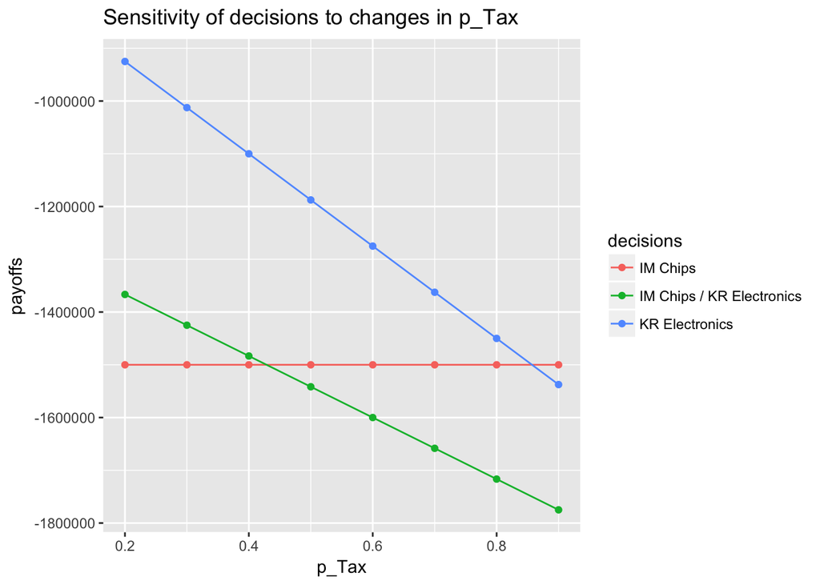

```r
sensitivity(
  resultVOIP,
  vars = "p_Tax 0.2 0.9 0.1;",
  decs = c("IM Chips", "IM Chips / KR Electronics", "KR Electronics"),
  custom = FALSE)
```

Buying all the chips from the IM Chips company doesn’t affect the total cost. Infact it remains the same for different values of the probability.

Buying half of the chips’ amount from IM Chips and the second half from KR Electronics will cost more to the copmpany if the probability is greater than 0.4.

Buying all the chips from KR Electronics is the better choice cause it will be more expansive for the company only in the case that the probability is greater than 0.86.

Eventually, the best choice for DM Systems is buying all the chips from KR Electronics (blue line).

## Utility Function and Certainty Equivalent

Assume that all the information in that exercise still holds, except assume now that DM has an exponential utility function with a risk tolerance of $750,000.

- Determine DM’s preferred ordering alternative using this utility function.

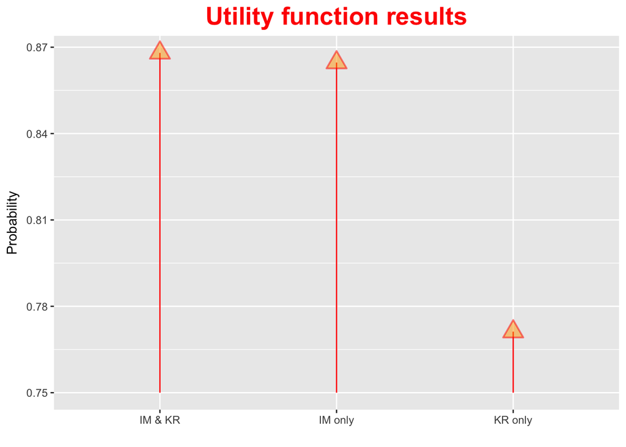

```r
utilityFunctionExp <- function(X, R) {
  res <- 1- exp(-X/R)
  return(res)
}
outcomes = c(1500000, 1500000, 1750000, 2250000, 1250000, 1125000, 1500000, 2250000, 750000)
utility = utilityFunctionExp(outcomes, 750000)
IM_only = utility[1]
IM_KR = 0.6*(1/3*utility[2]+1/3*utility[3]+1/3*utility[4])+0.4*utility[5]
KR_only = 0.6*(1/3*utility[6]+1/3*utility[7]+1/3*utility[8])+0.4*utility[9]
my_vector = c(IM_only, IM_KR, KR_only)
names_vector =c("IM only","IM & KR","KR only")
data=data.frame(x=names_vector, y=my_vector)
ggplot(data, aes(x=x, y=y)) +
  geom_segment(aes(x=x, xend=x, y=0.75, yend=y), color="red", size=0.5) +
  geom_point(size=5, color="red", fill=alpha("orange", 0.3), alpha=0.5, shape=24, stroke=1) +
  labs(title="Utility function results", x ="", y = "Probability") +
  theme(plot.title = element_text(colour="red", size=20, face="bold", hjust = 0.5))
```

As we can see, applying the utility function shows us that the best choice (with the higher probability) for DM Systems is buying half the amount of chips from IM Chips and the other half from KR Electronics.

## KR revises the offer

In an effort to attract DM’s order, KR Electronics has revised its offer as follows: At no increase in price, KR will now provide DM with the right to cancel its entire order for a 10% fee after the outcome of the antidumping suit is known. However, KR will not be able to accept any additional orders from DM once the outcome of the suit is known. Thus, for example, if DM has agreed to purchase 250,000 PAL chips from KR at $2.00 per chip, DM can cancel the order by paying $50,000. This ability to cancel the order is potentially of interest to DM because it knows that IM Chips would be able to supply PAL chips after the outcome of the antidumping suit is known in time for DM to fill the DISCO order.

However, DM knows that IM will increase the price of its chips if an antidumping tax is imposed. In particular, if a 50% tax is imposed, then IM will increase its chip price by 15%. If a 100% tax is imposed, then IM will increase its chip price by 20%. Finally, if a 200% tax is imposed, then IM will increase its chip price by 25%.

- Assuming that all other information is still valid, determine DM’s preferred alternative for the initial order of PAL chips as well as what DM should do if the antidumping tax is imposed.

```r
tree = yaml.load_file(input = "VOIPphones2.yaml") #loading the tree
resultVOIP =dtree(yl = tree)
plot(resultVOIP, final = TRUE)
```

[interactive chart not shown]

The optimal choice given by the expeted values is buying all the chips from the KR Electronics. However, it would be the best choice only if the final amount of tax will be 50% or 100%; In this case DM Systems shouldn’t cancel the order. If the amount of tax is 200%, DM Systems should cancel the previous order, pay the fee and order all the chips from IM Chips.

## Value of Information

Assume that all the information presented still holds. Using expected value as the decision criterion, determine the maximum amount that DM should pay for information about whether the antidumping tax will be imposed if this information can be obtained prior to making the ordering decision.

```r
tree = yaml.load_file(input = "VOIPphones3.yaml") #loading the tree
resultVOIP =dtree(yl = tree)
plot(resultVOIP, final = TRUE)
```

[interactive chart not shown]

```r
Perfect_info <- 1215000
Uncertain_info <- 1200000
Acc_payment <- Perfect_info - Uncertain_info
Acc_payment
```

```
## [1] 15000
```